# Florida Kestrel Occupancy Modeling

This is a fresh run-through of the occupancy modeling for American kestrels nesting in Florida, from 2008-2014. Note that there was no observations conducted during 2011.

Start with loading `runjags` and getting the input data. It needs to be transformed into a 3D array

```r
library(runjags)

getwd()
```

```
[1] "/Users/jlbrown/Science and School/KestrelProjects/_IPM_Updated"
```

```r
kesdat <- read.csv(file = "CombinedBimonthOccupancy.csv", header = T, row.names=1)
kesdat <- as.matrix(kesdat)
dim(kesdat)
```

```
[1] 90 56
```

There are 90 sites, 8 visits per year, and 7 years. Then make an initial conditions matrix. We can also find the naive occupancy by summing across the margins.

```r
y <- array(kesdat, dim = c(90, 8, 7))   # 90 sites, 8 reps, 7 years
#y <- y[,,-4]   # 90 sites, 8 reps, 6 years
z.init <- apply(y, c(1, 3), max, na.rm=T)
```

[output not shown]

[output cut: 139 more lines]

[output not shown]

```r
z.init[z.init == "-Inf"] <- NA
raw.occ <- apply(z.init, 2, sum, na.rm=T)
raw.occ
```

```
[1] 83 81 82  0 71 65 75
```

Now we’ll make a few helper functions/vectors, such as a sequential vector for the box checks, and defining the logit function.

```r
bimonth <- c(1:8)
# scale to z-standards
bimonth <- (bimonth-mean(bimonth))/sd(bimonth)
logit<-function(x){
log(x/(1-x))
}
```

# Occupancy model

Now we can write our occupancy model in JAGS, and, well, run it.

```r
# letting intercept of p effect vary by years
sink("DynoccQuadPT.jags")
cat("
    model {

    # Specify priors
    psi1 ~ dunif(0, 1)
    beta.p ~ dunif(-10,10)
    beta2.p ~ dunif(-10,10)

    for (k in 1:2){
      phi[k] ~ dunif(0, 1)
      gamma[k] ~ dunif(0, 1)
      alpha.p[k] ~ dunif(-3, 3)
      }
    for (k in 5:6){
      phi[k] ~ dunif(0, 1)
      gamma[k] ~ dunif(0, 1)
      alpha.p[(k-1)] ~ dunif(-3, 3)
    }
    alpha.p[3] ~ dunif(-3, 3)
    alpha.p[6] ~ dunif(-3, 3)

    phi[3] <- (phi[1]+phi[2]+phi[4]+phi[5]+phi[6])/5
    gamma[3] <- (gamma[1]+gamma[2]+gamma[4]+gamma[5]+gamma[6])/5
    p.miss <- 0

    phi[4] ~ dunif(0, 1)
    gamma[4] ~ dunif(0, 1)

    # Ecological submodel: Define state conditional on parameters
    for (i in 1:nsite){
      z[i,1] ~ dbern(psi1)
      for (k in 2:nyear){
            muZ[i,k]<- z[i,k-1]*phi[k-1] + (1-z[i,k-1])*gamma[k-1]
            z[i,k] ~ dbern(muZ[i,k])
            } #k
      } #i

    # Observation model
    for (i in 1:nsite){
      for (j in 1:nrep){
            for (k in 1:3){
                  muy[i,j,k] <- z[i,k]*p[i,j,k]
                  y[i,j,k] ~ dbern(muy[i,j,k])
                  logit(p[i,j,k]) <- alpha.p[k] + beta.p * bimonth[j] + beta2.p * pow(bimonth[j], 2)
                  } #k
            muy[i,j,4] <- z[i,4]*p.miss
            y[i,j,4] ~ dbern(muy[i,j,4])
            for (k in 5:nyear){
                  muy[i,j,k] <- z[i,k]*p[i,j,(k-1)]
                  y[i,j,k] ~ dbern(muy[i,j,k])
                  logit(p[i,j,(k-1)]) <- alpha.p[(k-1)] + beta.p * bimonth[j] + beta2.p * pow(bimonth[j], 2)
                  } #k
            } #j
      } #i

    # Derived parameters: Sample and population occupancy, growth rate and turnover
    psi[1] <- psi1
    n.occ[1]<-sum(z[1:nsite,1])
    mean.p[1] <- exp(alpha.p[1])/(1 + exp(alpha.p[1]))
    log.p[1] <- log(mean.p[1])
    for (k in 2:nyear){
      psi[k] <- psi[k-1]*phi[k-1] + (1-psi[k-1])*gamma[k-1]
      n.occ[k] <- sum(z[1:nsite,k])
      growthr[k-1] <- psi[k]/psi[k-1]
      turnover[k-1] <- (1 - psi[k-1]) * gamma[k-1]/psi[k]
      }
    for (k in 2:(nyear-1)){
      mean.p[k] <- exp(alpha.p[k])/(1 + exp(alpha.p[k]))
      log.p[k] <- log(mean.p[k])
    }
      overall.p <- exp((1/(nyear-1))*sum(log.p[1:(nyear-1)]))   # Geometric mean
    }
    ",fill = TRUE)
sink()

# Bundle data
win.data <- list(
      y = y,
      nsite = dim(y)[1],
      nrep = dim(y)[2],
      nyear = dim(y)[3],
      bimonth=bimonth)

# Initial values
inits <- function(){ list(z = z.init,
                          alpha.p = runif(6, -3, 3),
                          beta.p = runif(1, -3, 3),
                          beta2.p = runif(1, -3, 3))}

n.adapt <- 4000
n.update <- 1000
n.samp <- 1000
n.chains <- 2

set.seed(123)
outQPT <- run.jags("DynoccQuadPT.jags", data=win.data, inits=inits, n.chains=n.chains, sample=n.samp, method="parallel", monitor=c("psi", "phi", "gamma", "beta.p", "beta2.p", "n.occ", "growthr", "turnover", "mean.p"))
```

```
Calling 2 simulations using the parallel method...
Following the progress of chain 1 (the program will wait for
all chains to finish before continuing):
Welcome to JAGS 4.3.0 on Fri Jul 15 09:54:39 2022
JAGS is free software and comes with ABSOLUTELY NO WARRANTY
Loading module: basemod: ok
Loading module: bugs: ok
. . Reading data file data.txt
. Compiling model graph
. Reading parameter file inits1.txt
. Initializing model
. Adapting 1000
-------------------------------------------------| 1000
++++++++++++++++++++++++++++++++++++++++++++++++++ 100%
Adaptation successful
. Updating 4000
-------------------------------------------------| 4000
************************************************** 100%
. . . . . . . . . . Updating 1000
-------------------------------------------------| 1000
************************************************** 100%
. . . . Updating 0
. Deleting model
.
All chains have finished
Simulation complete.  Reading coda files...
Coda files loaded successfully
Calculating summary statistics...
Calculating the Gelman-Rubin statistic for 46 variables....
Finished running the simulation
```

```r
outQPT
```

```
JAGS model summary statistics from 2000 samples (chains = 2; adapt+burnin = 5000):

              Lower95   Median  Upper95     Mean       SD Mode
psi[1]        0.88199  0.93708  0.97973  0.93403 0.026677   --
psi[2]        0.82503  0.88987  0.94897  0.88769 0.032607   --
psi[3]        0.84126  0.90669  0.95792  0.90365 0.030756   --
psi[4]        0.81086  0.85494  0.89579    0.854 0.022504   --
psi[5]        0.70594  0.79462  0.86964  0.79114 0.042959   --
psi[6]        0.65098  0.75186  0.83761  0.75032  0.04831   --
psi[7]        0.76695  0.85167  0.91591  0.84865 0.039255   --
phi[1]        0.84678  0.91178  0.95933  0.90899  0.03018   --
phi[2]        0.90998  0.96183  0.99534  0.95831  0.02324   --
phi[3]        0.85234  0.88686  0.92152   0.8865 0.018081   --
phi[4]        0.71275  0.82787   0.9375  0.82486 0.059105   --
phi[5]        0.72461   0.8186   0.9094  0.81413  0.04886   --
phi[6]        0.86479  0.92979  0.98369   0.9262  0.03257   --
gamma[1]       0.2709  0.59422  0.91356  0.58591  0.17449   --
gamma[2]      0.18101   0.4667  0.74954  0.46967  0.15198   --
gamma[3]       0.4085  0.55311  0.68156   0.5527 0.071929   --
gamma[4]      0.14856   0.6044  0.99577   0.5856   0.2419   --
gamma[5]      0.27211  0.50899  0.71718  0.50841  0.11562   --
gamma[6]      0.41235  0.61841  0.81534  0.61389  0.10837   --
beta.p       -0.46501 -0.35321 -0.24926 -0.35095 0.054764   --
beta2.p       -1.0493 -0.91152 -0.79204  -0.9136 0.066845   --
n.occ[1]           84       85       85   84.912  0.31893   85
n.occ[2]           81       81       82   81.057  0.23618   81
n.occ[3]           82       83       84   82.752   0.8227   82
n.occ[4]           72       78       84   77.575   3.3281   78
n.occ[5]           71       72       74   72.273  0.73551   72
n.occ[6]           66       69       72   68.742   1.7222   68
n.occ[7]           77       78       79   77.716  0.65098   78
growthr[1]    0.87106   0.9508   1.0221  0.95087 0.037484   --
growthr[2]    0.95557   1.0165   1.0989   1.0187  0.03594   --
growthr[3]    0.90458  0.94527  0.98501  0.94551 0.020555   --
growthr[4]    0.83897  0.92813   1.0174  0.92648  0.04601   --
growthr[5]    0.81117  0.94717   1.0797  0.95037  0.06954   --
growthr[6]    0.99971   1.1294   1.2847   1.1346 0.074784   --
turnover[1] 0.0058697 0.040137  0.08676 0.043567  0.02226   --
turnover[2]  0.013307 0.054709  0.10889 0.058619 0.026425   --
turnover[3]  0.025453 0.059442   0.1026 0.062151 0.020876   --
```

[output cut: 44 more lines]

```
growthr[6]   0.0024832     3.3   907  -0.029633 0.99952
turnover[1] 0.00049277     2.2  2041   0.021362 0.99969
turnover[2]  0.0007947       3  1106 -0.0095469  1.0014
turnover[3] 0.00076417     3.7   746   0.057413   1.001
turnover[4]  0.0041892     8.2   148     0.2406  1.0011
turnover[5]  0.0012657       3  1147  -0.027347  1.0017
turnover[6]  0.0016713     3.5   832  -0.035036   1.001
mean.p[1]   0.00043178     3.8   697  -0.009759       1
mean.p[2]   0.00057716     4.4   525   0.053475  1.0002
mean.p[3]    0.0004705     3.5   803 -0.0028619  1.0141
mean.p[4]    0.0005124     3.8   706 -0.0017072  1.0017
mean.p[5]   0.00062734     3.8   680   0.016566  1.0025
mean.p[6]   0.00057139     3.9   651   0.038583       1

Total time taken: 36.6 seconds
```

That does indeed run, seems to be kind of, well, clunky in the priors and such. Let me see if I can re-write it to be less ugly. I think I will make a helper function to determine appropriate beta distribution parameter values for some of the priors.

```r
# a function for beta distribution parameter estimation
estBetaParams <- function(mu, var){
  alpha <- ((1 - mu) / var - 1/mu) * mu ^ 2
  beta <- alpha * (1 / mu -1)
  return(params = list(alpha = alpha, beta = beta))
}

estBetaParams(0.95, 0.0225) # for 95 value, 15 SD
```

```
$alpha
[1] 1.055556

$beta
[1] 0.05555556
```

What about a 50% with perhaps 15 variability (for gamma)?

```r
estBetaParams(0.5, 0.0225)
```

```
$alpha
[1] 5.055556

$beta
[1] 5.055556
```

```r
# letting intercept of p effect vary by years
sink("DynoccQuadPT.jags")
cat("
    model {

    # Specify priors
    psi1 ~ dunif(0, 1)
    beta.p ~ dt(0, 1/2.5^2, 1)
    beta2.p ~ dt(0, 1/2.5^2, 1)

    for (k in 1:2){
      phi[k] ~ dunif(0, 1)
      gamma[k] ~ dunif(0, 1)
      alpha.p[k] ~ dt(0, 1/2.5^2, 1)
      }
    for (k in 4:6){
      phi[k] ~ dunif(0, 1)
      gamma[k] ~ dunif(0, 1)
      alpha.p[k] ~ dt(0, 1/2.5^2, 1)
    }
    alpha.p[3] ~ dt(0, 1/2.5^2, 1)

    phi[3] <- (phi[1]+phi[2]+phi[4]+phi[5]+phi[6])/5
    gamma[3] <- (gamma[1]+gamma[2]+gamma[4]+gamma[5]+gamma[6])/5
    p.miss <- 0

    # Ecological submodel: Define state conditional on parameters
    for (i in 1:nsite){
      z[i,1] ~ dbern(psi1)
      for (k in 2:nyear){
            muZ[i,k]<- z[i,k-1]*phi[k-1] + (1-z[i,k-1])*gamma[k-1]
            z[i,k] ~ dbern(muZ[i,k])
            } #k
      } #i

    # Observation model
    for (i in 1:nsite){
      for (j in 1:nrep){
            for (k in 1:3){
                  muy[i,j,k] <- z[i,k]*p[i,j,k]
                  y[i,j,k] ~ dbern(muy[i,j,k])
                  logit(p[i,j,k]) <- alpha.p[k] + beta.p * bimonth[j] + beta2.p * pow(bimonth[j], 2)
                  } #k
            muy[i,j,4] <- z[i,4]*p.miss
            y[i,j,4] ~ dbern(muy[i,j,4])
            for (k in 5:nyear){
                  muy[i,j,k] <- z[i,k]*p[i,j,(k-1)]
                  y[i,j,k] ~ dbern(muy[i,j,k])
                  logit(p[i,j,(k-1)]) <- alpha.p[(k-1)] + beta.p * bimonth[j] + beta2.p * pow(bimonth[j], 2)
                  } #k
            } #j
      } #i

    # Derived parameters: Sample and population occupancy, growth rate and turnover
    psi[1] <- psi1
    n.occ[1]<-sum(z[1:nsite,1])
    mean.p[1] <- exp(alpha.p[1])/(1 + exp(alpha.p[1]))
    log.p[1] <- log(mean.p[1])
    for (k in 2:nyear){
      psi[k] <- psi[k-1]*phi[k-1] + (1-psi[k-1])*gamma[k-1]
      n.occ[k] <- sum(z[1:nsite,k])
      growthr[k-1] <- psi[k]/psi[k-1]
      turnover[k-1] <- (1 - psi[k-1]) * gamma[k-1]/psi[k]
      }
    for (k in 2:(nyear-1)){
      mean.p[k] <- exp(alpha.p[k])/(1 + exp(alpha.p[k]))
      log.p[k] <- log(mean.p[k])
    }
      overall.p <- exp((1/(nyear-1))*sum(log.p[1:(nyear-1)]))   # Geometric mean
    }
    ",fill = TRUE)
sink()

# Bundle data
win.data <- list(
      y = y,
      nsite = dim(y)[1],
      nrep = dim(y)[2],
      nyear = dim(y)[3],
      bimonth=bimonth)

# Initial values
inits <- function(){ list(z = z.init,
                          alpha.p = runif(6, -5, 5),
                          beta.p = runif(1, -3, 3),
                          beta2.p = runif(1, -3, 3))}

n.adapt <- 4000
n.update <- 1000
n.samp <- 1000
n.chains <- 2

set.seed(123)
outQPT <- run.jags("DynoccQuadPT.jags", data=win.data, inits=inits, n.chains=n.chains, sample=n.samp, method="parallel", monitor=c("psi", "phi", "gamma", "beta.p", "beta2.p", "n.occ", "growthr", "turnover", "mean.p"))
```

```
Calling 2 simulations using the parallel method...
Following the progress of chain 1 (the program will wait for
all chains to finish before continuing):
Welcome to JAGS 4.3.0 on Fri Jul 15 09:55:17 2022
JAGS is free software and comes with ABSOLUTELY NO WARRANTY
Loading module: basemod: ok
Loading module: bugs: ok
. . Reading data file data.txt
. Compiling model graph
. Reading parameter file inits1.txt
. Initializing model
. Adapting 1000
-------------------------------------------------| 1000
++++++++++++++++++++++++++++++++++++++++++++++++++ 100%
Adaptation successful
. Updating 4000
-------------------------------------------------| 4000
************************************************** 100%
. . . . . . . . . . Updating 1000
-------------------------------------------------| 1000
************************************************** 100%
. . . . Updating 0
. Deleting model
.
All chains have finished
Simulation complete.  Reading coda files...
Coda files loaded successfully
Calculating summary statistics...
Calculating the Gelman-Rubin statistic for 46 variables....
Finished running the simulation
```

```r
outQPT
```

```
JAGS model summary statistics from 2000 samples (chains = 2; adapt+burnin = 5000):

              Lower95   Median  Upper95     Mean       SD Mode
psi[1]        0.88587  0.93795  0.98178  0.93452 0.026217   --
psi[2]        0.82275  0.89104  0.94626  0.88844 0.032554   --
psi[3]        0.84844  0.90779   0.9637  0.90548 0.030203   --
psi[4]        0.80907  0.85617  0.89625  0.85556 0.022321   --
psi[5]        0.71012  0.79304  0.87208  0.79105 0.041612   --
psi[6]        0.65757  0.75568  0.84844  0.75344  0.04947   --
psi[7]        0.77589  0.84975  0.92378    0.848 0.037683   --
phi[1]        0.85092  0.91332   0.9629  0.90935 0.030767   --
phi[2]        0.91426  0.96356   0.9947  0.96027 0.022256   --
phi[3]        0.85372  0.88909  0.92119  0.88789 0.017659   --
phi[4]        0.71456   0.8307   0.9431  0.82739 0.059107   --
phi[5]        0.70794   0.8184  0.90471  0.81719 0.050338   --
phi[6]        0.86233  0.92961  0.98224  0.92524 0.032631   --
gamma[1]      0.26344  0.60008  0.89885  0.58991  0.16954   --
gamma[2]      0.19523   0.4683  0.76002  0.46879  0.14893   --
gamma[3]      0.41379  0.55142  0.70329  0.54983 0.074163   --
gamma[4]       0.1192  0.58887   0.9969  0.56764  0.25687   --
gamma[5]      0.27476  0.51152  0.74373  0.51274  0.12104   --
gamma[6]       0.4195  0.61458  0.82449  0.61007  0.10417   --
beta.p       -0.45031 -0.34847  -0.2567 -0.34924 0.050072   --
beta2.p       -1.0106 -0.89381  -0.7526 -0.89353 0.065808   --
n.occ[1]           84       85       85   84.917  0.32736   85
n.occ[2]           81       81       82   81.064     0.25   81
n.occ[3]           82       83       84   82.781  0.81526   82
n.occ[4]           70       78       83   77.646   3.3546   78
n.occ[5]           71       72       74   72.251  0.72888   72
n.occ[6]           66       69       72    68.93   1.8197   68
n.occ[7]           77       78       79   77.725  0.65543   78
growthr[1]    0.87691  0.95239    1.029  0.95119 0.038141   --
growthr[2]    0.94771   1.0193   1.0887   1.0199 0.035392   --
growthr[3]    0.90589  0.94455  0.98251  0.94528 0.019698   --
growthr[4]    0.83514  0.92608   1.0124  0.92474  0.04521   --
growthr[5]    0.80715  0.95121   1.0899  0.95443 0.072163   --
growthr[6]    0.99346   1.1229   1.2799   1.1292 0.074299   --
turnover[1]  0.007524 0.040139 0.087063 0.043519 0.022016   --
turnover[2]  0.015596 0.054816  0.10787 0.057831 0.025232   --
turnover[3]  0.024424 0.058812  0.10093 0.060475 0.020286   --
```

[output cut: 44 more lines]

```
growthr[6]   0.0024711     3.3   904   0.0064344 0.99954
turnover[1]  0.0005668     2.6  1509   0.0071275  1.0044
turnover[2] 0.00078523     3.1  1033  -0.0035847   1.003
turnover[3]  0.0008297     4.1   598    0.058817  1.0101
turnover[4]  0.0046291     8.8   129     0.28316  1.0268
turnover[5]  0.0012449     2.9  1168   -0.023199  1.0012
turnover[6]  0.0016391     3.4   877  -0.0071404  1.0013
mean.p[1]   0.00045651     3.8   692   -0.025943  1.0088
mean.p[2]   0.00069758       5   395    0.021899  1.0004
mean.p[3]   0.00051712     3.9   665    0.015817  1.0078
mean.p[4]    0.0004487     3.4   851  -0.0037542 0.99971
mean.p[5]   0.00072002       4   639    0.030842 0.99969
mean.p[6]   0.00059062     4.1   589    0.025748  1.0043

Total time taken: 47.2 seconds
```

Can I get a DIC out of this?

```r
extract.runjags(outQPT, "dic")
```

[output not shown]

Let’s pull out some of the output. And then write to disk Then, let’s extend the model and get some more statistics/parameters.

```r
library(coda)
outQPT.coda <- as.mcmc.list(outQPT)

outQPT.out <- summary(outQPT, vars=c("n.occ"))
n.occ.QPT <- outQPT.out[,2]
sd.n.occ.QPT <- outQPT.out[,5]
write.csv(outQPT$BUGSoutput$summary, "OccupancyModelOutput_2022-02-23.csv")

outQPT.p <- extend.jags(outQPT, drop.monitor=c("psi", "phi", "gamma", "beta.p", "beta2.p", "n.occ", "growthr", "turnover", "mean.p"), add.monitor=c("alpha.p", "beta.p", "beta2.p", "mean.p", "overall.p"), sample=2000)
```

```
Calling 2 simulations using the parallel method...
Following the progress of chain 1 (the program will wait for
all chains to finish before continuing):
Welcome to JAGS 4.3.0 on Fri Jul 15 09:56:43 2022
JAGS is free software and comes with ABSOLUTELY NO WARRANTY
Loading module: basemod: ok
Loading module: bugs: ok
. . Reading data file data.txt
. Compiling model graph
. Reading parameter file inits1.txt
. Initializing model
. Adapting 1000
-------------------------------------------------| 1000
++++++++++++++++++++++++++++++++++++++++++++++++++ 100%
Adaptation successful
. NOTE: Stopping adaptation

. . . . . Updating 2000
-------------------------------------------------| 2000
************************************************** 100%
. . . . Updating 0
. Deleting model
.
All chains have finished
Simulation complete.  Reading coda files...
Coda files loaded successfully
Calculating summary statistics...
Calculating the Gelman-Rubin statistic for 15 variables....
Finished running the simulation
```

```r
outQPT.p.coda <- as.mcmc.list(outQPT.p)
print(outQPT.p, dig = 4)
```

```
JAGS model summary statistics from 4000 samples (chains = 2; adapt+burnin = 7000):

           Lower95  Median Upper95    Mean       SD Mode     MCerr
alpha.p[1]   1.988   2.235   2.517   2.236   0.1369   --  0.003863
alpha.p[2]   1.703   1.955   2.192   1.957   0.1266   --  0.004248
alpha.p[3]   1.869   2.132    2.42   2.136   0.1418   --   0.00401
alpha.p[4]   1.808   2.085    2.36   2.086   0.1403   --  0.003996
alpha.p[5]   1.998   2.478   2.983   2.481   0.2503   --  0.007183
alpha.p[6]   1.688   1.944   2.203   1.944   0.1321   --   0.00415
beta.p     -0.4589 -0.3517 -0.2531 -0.3529  0.05335   --  0.001181
beta2.p      -1.03 -0.8977  -0.765 -0.8977  0.06708   --   0.00284
mean.p[1]   0.8795  0.9033  0.9253  0.9028  0.01205   -- 0.0003392
mean.p[2]   0.8489  0.8759  0.9021  0.8755  0.01371   -- 0.0004568
mean.p[3]   0.8664   0.894  0.9183  0.8936   0.0134   -- 0.0003782
mean.p[4]   0.8623  0.8895  0.9165  0.8887  0.01385   -- 0.0003884
mean.p[5]   0.8849  0.9226   0.955  0.9209  0.01822   -- 0.0005237
mean.p[6]   0.8445  0.8748  0.9009  0.8741  0.01452   -- 0.0004355
overall.p    0.875  0.8926   0.908  0.8924 0.008509   -- 0.0003627

           MC%ofSD SSeff     AC.10  psrf
alpha.p[1]     2.8  1255   0.02438     1
alpha.p[2]     3.4   889   0.01813 1.001
alpha.p[3]     2.8  1250   0.01268     1
alpha.p[4]     2.8  1232 0.0008451     1
alpha.p[5]     2.9  1214 0.0001611     1
alpha.p[6]     3.1  1014   0.01019 1.006
beta.p         2.2  2039  0.008965     1
beta2.p        4.2   558   0.07888 1.001
mean.p[1]      2.8  1263   0.02449     1
mean.p[2]      3.3   901   0.01715 1.001
mean.p[3]      2.8  1256   0.01169     1
mean.p[4]      2.8  1271 0.0007289     1
mean.p[5]      2.9  1210  0.005221     1
mean.p[6]        3  1112   0.01504 1.006
overall.p      4.3   550   0.07461 1.001

Total time taken: 1.4 minutes
```

Let’s figure out how many surveys are needed to detect kestrels, given they are there. This version simply uses the overall mean p - which does not vary by sample date. Hence, it is not as realistic as stepping through using the actual biweekly value.

```r
Pstar <- array(NA, dim = c(2000, 8))
x <- cbind(rep(1, 2000), rep(2, 2000), rep(3, 2000), rep(4, 2000), rep(5, 2000), rep(6, 2000), rep(7, 2000), rep(8, 2000))
for (i in 1:2000) {
    for (j in 1:8){
        Pstar[i,j] <- 1 - (1 - outQPT.p.coda[[1]][i,15])^j
        } #j
    } #i
{pdf("SurveysWithCumulativeDetectionProbGeneral.pdf", width = 6, height = 4)
op <- par(mar = c(5,6,4,2) + 0.1)
  boxplot(Pstar ~ x, col = "gray", las = 1, ylab = "Probability of\nOccupancy Detection", xlab = "Total Number of Surveys",
          outline = FALSE, ylim = c(0.5,1))
  legend("bottomright", legend="A", cex = 2, bty="n")
abline(h = 0.95, lty = 2, lwd = 2)
par(op)
dev.off()}
```

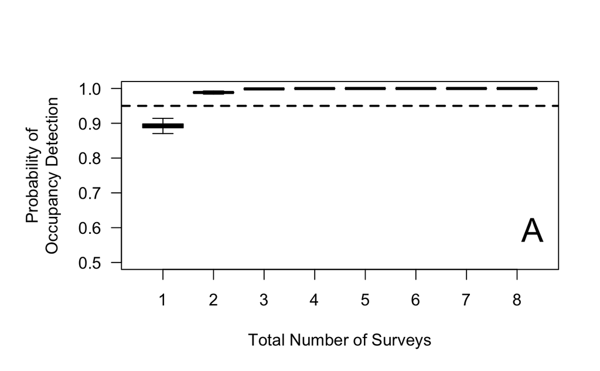

```r
{op <- par(mar = c(5,6,4,2) + 0.1)
  boxplot(Pstar ~ x, col = "gray", las = 1, ylab = "Probability of\nOccupancy Detection", xlab = "Total Number of Surveys",
          outline = FALSE, ylim = c(0.5,1))
  legend("bottomright", legend="A", cex = 2, bty="n")
abline(h = 0.95, lty = 2, lwd = 2)
par(op)}
```

# Now let’s investigate survey timing effects.

This is based on the intercept for p in the year 2 of the study, which is a low year for detection probs.

```r
mcmc.sample <- outQPT.p$BUGSoutput$n.sims

date.pred <- bimonth
p.pred.date <- plogis(summary(outQPT.p.coda)$statistics[2,1] + summary(outQPT.p.coda)$statistics[7,1] * date.pred + summary(outQPT.p.coda)$statistics[8,1] * date.pred^2)

array.p.pred.date <- array(NA, dim = c(length(date.pred), 2000))
for (i in 1:2000){
   array.p.pred.date[,i] <- plogis(outQPT.p.coda[[1]][i,2] + outQPT.p.coda[[1]][i,7] * date.pred + outQPT.p.coda[[1]][i,8] * date.pred^2)
   }
```

## Plot for a subsample of MCMC draws

We want to update the x axis to have text in it, instead of those numbers. This is a base R plot so I need to figure this out…

## Suppress the axis

```r
{pdf("DetectionProbabilityAcrossYear_2022-07-15.pdf")
  plot(c(1:8), p.pred.date, main = "", ylab = "Detection Probability", xlab = "Survey Timing", ylim = c(0, 1), type = "l", lwd = 3, frame.plot = FALSE, xaxt = "n")
  axis(side = 1, at = c(1:8), labels=c("1 Mar", "15 Mar", "1 Apr", "15 Apr", "1 May", "15 May","1 Jun","15 Jun"))
for (i in sub.set){
   lines(c(1:8), array.p.pred.date[,i], type = "l", lwd = 1, col = "gray")
   }
lines(c(1:8), p.pred.date, type = "l", lwd = 3, col = "black")
dev.off()}
```

## Figuring out how prod and cumprod work

```r
1-((1-p.pred.date[1])*(1-p.pred.date[2])*(1-p.pred.date[3])*(1-p.pred.date[4])*(1-p.pred.date[5])*(1-p.pred.date[6])*(1-p.pred.date[7])*(1-p.pred.date[8]))
```

```
[1] 0.9999935
```

```r
1-prod(1-p.pred.date)
```

```
[1] 0.9999935
```

```r
1-cumprod(1-p.pred.date) # for all 8 sequentially
```

```
[1] 0.6503692 0.9293870 0.9902266 0.9988187 0.9998382 0.9999680
[7] 0.9999891 0.9999935
```

```r
1-cumprod(1-p.pred.date[2:8]) # starting at 2nd week
```

```
[1] 0.7980356 0.9720464 0.9966212 0.9995373 0.9999084 0.9999687
[7] 0.9999814
```

```r
1-cumprod(1-p.pred.date[3:8])
```

```
[1] 0.8615917 0.9832703 0.9977090 0.9995464 0.9998452 0.9999080
```

```r
1-cumprod(1-p.pred.date[4:8])
```

```
[1] 0.8791278 0.9834476 0.9967225 0.9988815 0.9993352
```

```r
1-cumprod(1-p.pred.date[5:8])
```

```
[1] 0.8630589 0.9728843 0.9907468 0.9944999
```

```r
1-cumprod(1-p.pred.date[6:8])
```

```
[1] 0.8019900 0.9324295 0.9598360
```

```r
1-cumprod(1-p.pred.date[7:8])
```

```
[1] 0.6587521 0.7971617
```

OK, let’s redo using the cumprod function and the full array, which has all the uncertainty propagated through. You’ll note that the second check ends up very close to 0.95, so a third would be better than not doing.

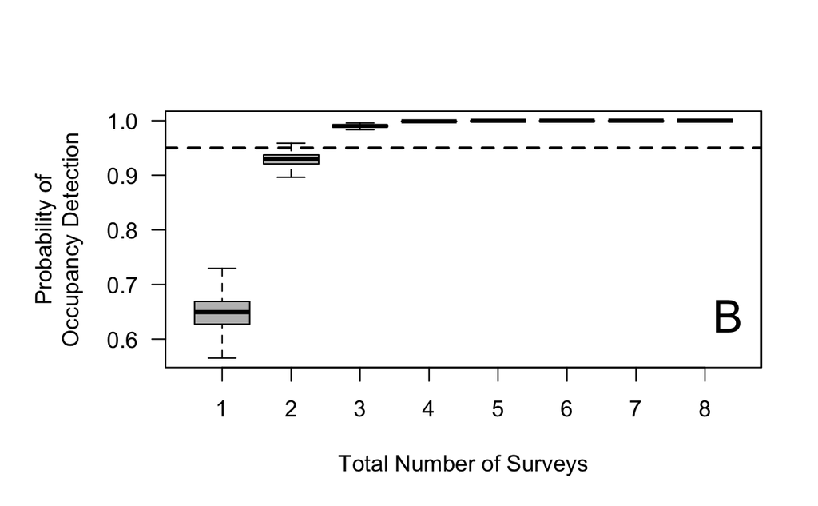

Let’s try a different method yet.

```r
ggsave("SixScenarios.pdf")
```

```
Warning: Removed 34000 rows containing non-finite values (stat_boxplot).
```

## Requested by Karl to do a version with 8 surveys, 6 surveys, then 1 Apr, 1 May, 1 Jun (3,5,7)

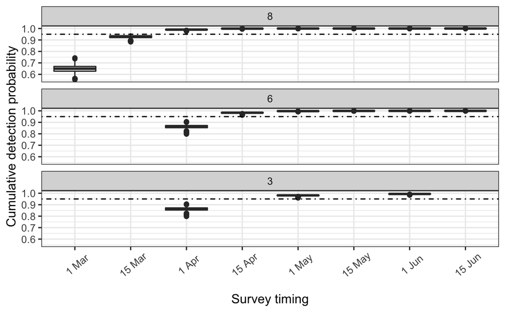

```r
Pstar <- data.frame(V1=rep(NA,2000*3), V2=rep(NA,2000*3), V3=rep(NA,2000*3), V4=rep(NA,2000*3), V5=rep(NA,2000*3), V6=rep(NA,2000*3), V7=rep(NA,2000*3), V8=rep(NA,2000*3), NumSurveys=c(rep(8,2000),rep(6,2000),rep(3,2000)))

for (i in 1:2000) {
      Pstar[i,1:8] <- 1-cumprod(1-array.p.pred.date[1:8,i])
} #i
for (i in 2001:4000) {
      Pstar[i,3:8] <- 1-cumprod(1-array.p.pred.date[3:8,i-2000])
} #i
for (i in 4001:6000) {
      Pstar[i,c(3,5,7)] <- 1-cumprod(1-array.p.pred.date[c(3,5,7),i-4000])
} #i
Pstar$NumSurveys <- factor(Pstar$NumSurveys, levels=c("8","6","3"))

Pstar.melt <- melt(Pstar, id.vars="NumSurveys")

p <- ggplot(Pstar.melt, aes(factor(variable), value))
p + geom_boxplot() +
  facet_wrap(~NumSurveys, ncol=1) +
  labs(x="Survey timing", y="Cumulative detection probability") +
  geom_hline(yintercept = 0.95, linetype="dotdash") +
  scale_x_discrete(labels=c("1 Mar", "15 Mar", "1 Apr", "15 Apr", "1 May","15 May","1 Jun","15 Jun")) +
  theme_bw() +
  theme(axis.text.x=element_text(angle=40, margin = margin(t = 10, r = 0, b = 0, l = 0)))
```

```
Warning: Removed 14000 rows containing non-finite values (stat_boxplot).
```

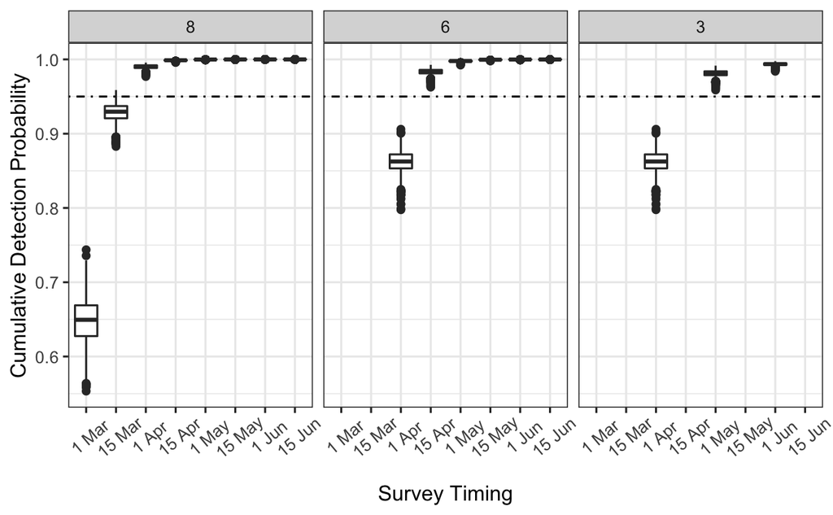

```r
p + geom_boxplot() +
  facet_wrap(~NumSurveys, nrow=1) +
  labs(x="Survey Timing", y="Cumulative Detection Probability") +
  geom_hline(yintercept = 0.95, linetype="dotdash") +
  scale_x_discrete(labels=c("1 Mar", "15 Mar", "1 Apr", "15 Apr", "1 May","15 May","1 Jun","15 Jun")) +
  theme_bw() +
  theme(axis.text.x=element_text(angle=40, margin = margin(t = 10, r = 0, b = 0, l = 0)))
ggsave("SurveyScenario.pdf")
```

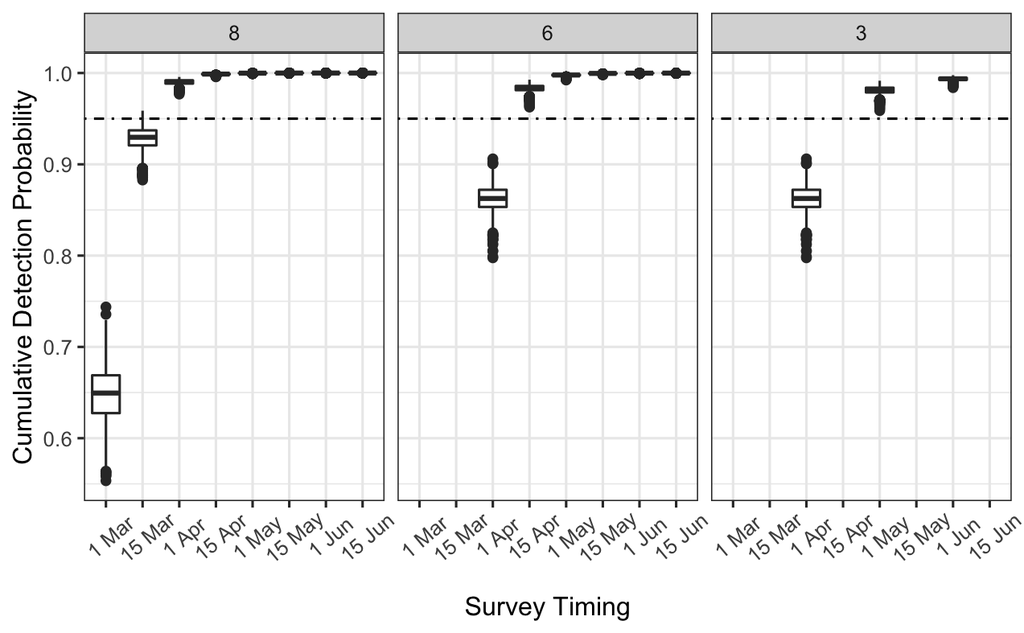

```r
p + geom_boxplot() +
  facet_wrap(~NumSurveys, nrow=1) +
  labs(x="Survey Timing", y="Cumulative Detection Probability") +
  geom_hline(yintercept = 0.95, linetype="dotdash") +
  scale_x_discrete(labels=c("1 Mar", "15 Mar", "1 Apr", "15 Apr", "1 May","15 May","1 Jun","15 Jun")) +
  theme_bw() +
  theme(axis.text.x=element_text(angle=40, margin = margin(t = 10, r = 0, b = 0, l = 0)))
```

# Plot the estimated occupancy versus raw counts

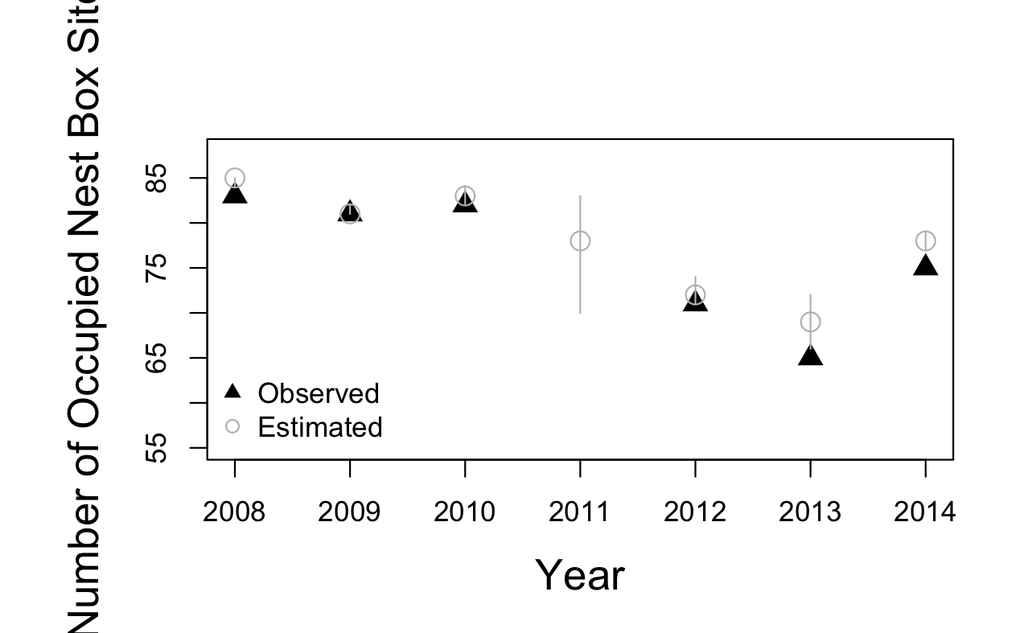